# Exam

Now make a random sample of 40 house prices and calculate the sample mean:

```r
'First of all we make a random sample (40 elements) of the price vector, with the next command:'
```

```
## [1] "First of all we make a random sample (40 elements) of the price vector, with the next command:"
```

```r
y <- sample(price, 40)
y
```

```
##  [1] 2.400 3.200 1.535 1.175 2.290 0.595 1.675 4.100 1.995 1.235 1.395
## [12] 2.300 3.075 1.950 1.775 2.150 2.555 1.075 2.000 1.045 1.775 2.260
## [23] 1.170 2.295 4.200 2.400 1.150 0.630 5.500 1.025 1.970 0.980 1.895
## [34] 0.635 1.750 1.520 1.490 0.780 0.300 0.635
```

```r
'and we calculate the mean for this new sample'
```

```
## [1] "and we calculate the mean for this new sample"
```

```r
mean_valuey<-mean(y)
mean_valuey
```

```
## [1] 1.847
```

```r
'this is the actual mean of the other sample(80000 elements) calculated previously:'
```

```
## [1] "this is the actual mean of the other sample(80000 elements) calculated previously:"
```

```r
mean_value<-mean(price)
mean_value
```

```
## [1] 1.929
```

Repeat this command a few times. Is each mean price close to what you expected?

Use `replicate` to repeat the sampling 200 times and save each mean value in the vector `y_bar`:

```r
'so now we take 200 means of a vector of different 40 samples.'
```

```
## [1] "so now we take 200 means of a vector of different 40 samples."
```

```r
y_bar2 <- replicate(200, mean(sample(price, 40)))
y_bar2
```

```
##   [1] 1.680 1.968 1.943 1.947 2.034 1.773 2.067 2.240 1.619 2.499 1.841
##  [12] 1.972 1.955 2.097 1.924 1.885 2.125 1.839 1.869 1.924 1.815 1.665
##  [23] 1.910 2.004 1.902 1.823 2.153 1.844 1.766 1.951 1.759 1.935 1.707
##  [34] 1.769 1.880 1.928 2.042 1.743 2.043 2.111 2.067 1.759 1.842 2.109
##  [45] 1.844 2.296 1.958 2.051 1.973 1.921 2.231 1.768 1.658 2.018 2.272
##  [56] 2.061 2.136 2.068 2.017 2.019 2.266 1.808 1.574 1.967 2.142 2.302
##  [67] 2.232 1.915 2.103 1.784 2.095 2.115 1.905 1.468 1.748 2.101 2.088
##  [78] 1.776 1.743 1.934 1.660 1.947 1.786 1.915 1.615 1.835 1.973 2.040
##  [89] 2.077 1.869 2.157 1.716 2.119 2.213 1.712 1.879 2.288 1.862 1.871
## [100] 2.278 2.106 2.234 1.863 2.288 2.035 1.821 1.894 2.194 2.171 1.735
## [111] 1.793 1.996 1.829 2.236 1.926 1.909 2.334 1.831 2.171 2.146 1.888
## [122] 1.832 1.839 1.646 1.739 1.954 1.880 1.809 2.644 2.389 2.211 2.017
## [133] 2.328 2.006 1.893 1.720 1.709 1.832 2.138 2.127 1.748 1.624 1.645
## [144] 1.488 1.683 1.926 2.023 2.302 2.078 1.889 2.122 1.987 1.977 2.278
## [155] 1.625 1.956 1.800 1.899 2.113 2.109 1.794 1.951 1.682 1.838 1.721
## [166] 1.859 2.158 1.999 2.046 2.058 2.126 1.830 1.691 1.721 1.872 1.969
## [177] 1.733 1.587 1.880 1.852 1.821 1.851 2.015 2.009 2.002 1.686 2.150
## [188] 1.819 1.795 1.693 2.066 1.750 2.135 1.834 1.891 2.059 2.164 2.051
## [199] 1.930 1.742
```

Calculate the mean and standard deviation of the values in `y_bar`.

```r
Final_mean<-mean(y_bar2)
Final_mean
```

```
## [1] 1.946
```

```r
Final_standard_deviation<-sd(y_bar2)
Final_standard_deviation
```

```
## [1] 0.1958
```

```r
'Now we compare these values to the first 80000 elements mean and standard deviation and we expect that it will be more or less the same
page100 example interestinf'
```

```
## [1] "Now we compare these values to the first 80000 elements mean and standard deviation and we expect that it will be more or less the same\npage100 example interestinf"
```

```r
y_bar
```

```
## [1] 1.929
```

```r
se
```

```
## [1] 0.2015
```

- How do they match with what you expected?
- Make a histogram of the values in `y_bar` and add the density curve for the approximate distribution you predicted previously using `plotDist` with the argument `add = TRUE`. For example if you predicted a normal distribution with mean 2 and standard deviation 0.2:

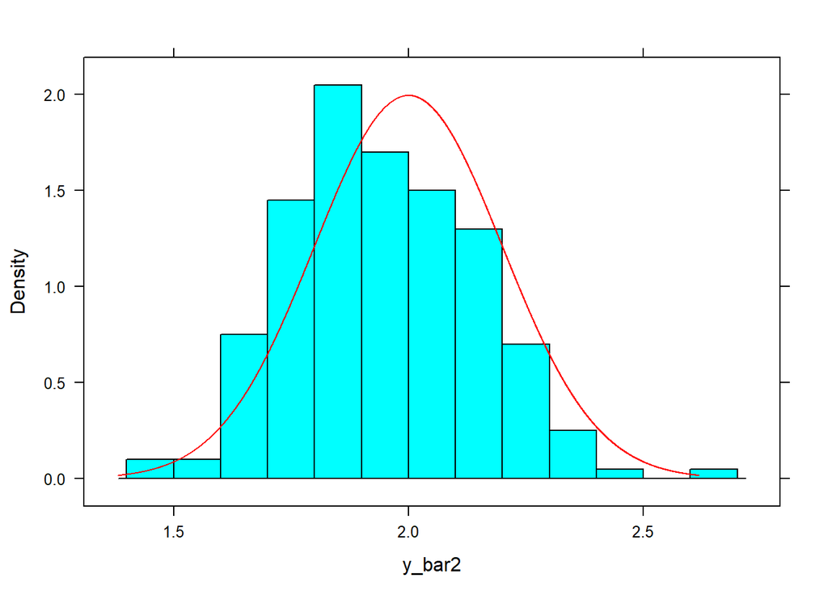

```r
histogram(y_bar2, breaks = 15, type = "density")
plotDist("norm", mean = 2, sd = 0.2, add = TRUE, col = "red")
```

- Make a boxplot of `y_bar` and explain how a boxplot is constructed.

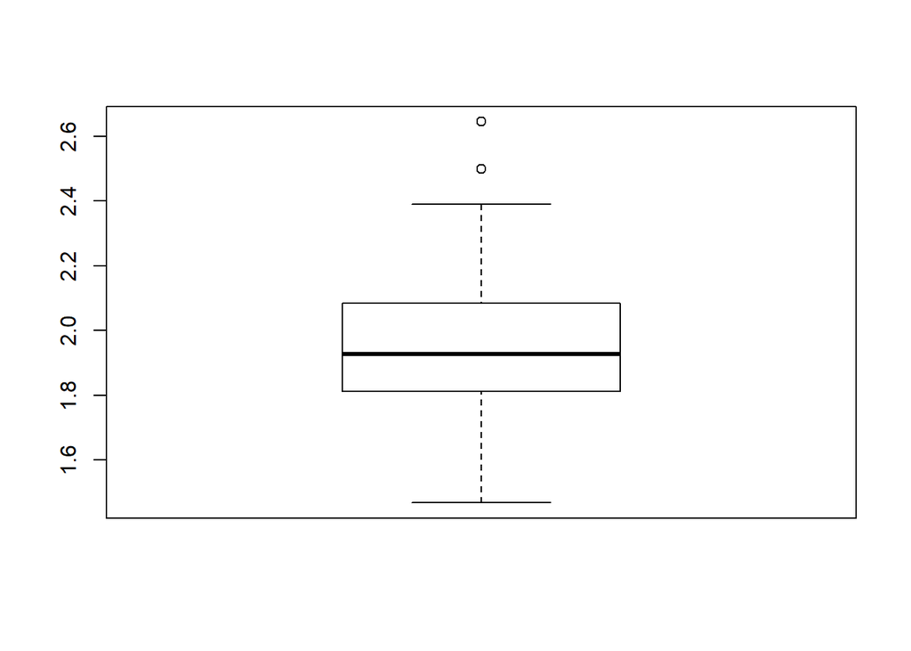

```r
boxplot(y_bar2)
```

# Part III: Theoretical boxplot for a normal distribution